# Using caret, an example

Ryan Miller

## Predicting Diabetes Status

- Lately we’ve been working with modeling approaches using `caret`
- Today we go through an example demonstrating how you might use `caret`
- We will use the `PimaIndiansDiabetes` data, our goal will be to develop a model that predicts diabetes, we’ll also look at ways to communicate the results of that model

```r
library(ggplot2) ## For plotting
library(caret) ## For model training/evaluation
library(class) ## For knn models
library(randomForest) ## For rf models
library(kernlab) ## For SVM models
library(mlbench) ## Contains example data set
library(tidyr) ## For data manipulation
library(dplyr) ## For data manipulation
library(DMwR) ## For knn imputation
library(kableExtra) ## For nice html tables
library(iml) ## For interpretting ML models

data("PimaIndiansDiabetes")

## Create a training and testing split
set.seed(25)
test.id <- sample(1:nrow(PimaIndiansDiabetes), size = .2*nrow(PimaIndiansDiabetes))

train.data <- PimaIndiansDiabetes[-test.id,]
test.data <- PimaIndiansDiabetes[test.id,]


knitr::kable(train.data) %>%
  kable_styling(bootstrap_options = "hover") %>%
  scroll_box(width = "100%", height = "300px")
```

|  | pregnant | glucose | pressure | triceps | insulin | mass | pedigree | age | diabetes |
| --- | --- | --- | --- | --- | --- | --- | --- | --- | --- |
| 1 | 6 | 148 | 72 | 35 | 0 | 33.6 | 0.627 | 50 | pos |
| 2 | 1 | 85 | 66 | 29 | 0 | 26.6 | 0.351 | 31 | neg |
| 3 | 8 | 183 | 64 | 0 | 0 | 23.3 | 0.672 | 32 | pos |
| 4 | 1 | 89 | 66 | 23 | 94 | 28.1 | 0.167 | 21 | neg |
| 5 | 0 | 137 | 40 | 35 | 168 | 43.1 | 2.288 | 33 | pos |
| 6 | 5 | 116 | 74 | 0 | 0 | 25.6 | 0.201 | 30 | neg |
| 8 | 10 | 115 | 0 | 0 | 0 | 35.3 | 0.134 | 29 | neg |
| 9 | 2 | 197 | 70 | 45 | 543 | 30.5 | 0.158 | 53 | pos |
| 10 | 8 | 125 | 96 | 0 | 0 | 0.0 | 0.232 | 54 | pos |
| 11 | 4 | 110 | 92 | 0 | 0 | 37.6 | 0.191 | 30 | neg |
| 12 | 10 | 168 | 74 | 0 | 0 | 38.0 | 0.537 | 34 | pos |
| 13 | 10 | 139 | 80 | 0 | 0 | 27.1 | 1.441 | 57 | neg |
| 14 | 1 | 189 | 60 | 23 | 846 | 30.1 | 0.398 | 59 | pos |
| 15 | 5 | 166 | 72 | 19 | 175 | 25.8 | 0.587 | 51 | pos |
| 16 | 7 | 100 | 0 | 0 | 0 | 30.0 | 0.484 | 32 | pos |
| 17 | 0 | 118 | 84 | 47 | 230 | 45.8 | 0.551 | 31 | pos |
| 18 | 7 | 107 | 74 | 0 | 0 | 29.6 | 0.254 | 31 | pos |
| 20 | 1 | 115 | 70 | 30 | 96 | 34.6 | 0.529 | 32 | pos |
| 21 | 3 | 126 | 88 | 41 | 235 | 39.3 | 0.704 | 27 | neg |
| 23 | 7 | 196 | 90 | 0 | 0 | 39.8 | 0.451 | 41 | pos |
| 24 | 9 | 119 | 80 | 35 | 0 | 29.0 | 0.263 | 29 | pos |
| 25 | 11 | 143 | 94 | 33 | 146 | 36.6 | 0.254 | 51 | pos |
| 26 | 10 | 125 | 70 | 26 | 115 | 31.1 | 0.205 | 41 | pos |
| 27 | 7 | 147 | 76 | 0 | 0 | 39.4 | 0.257 | 43 | pos |
| 28 | 1 | 97 | 66 | 15 | 140 | 23.2 | 0.487 | 22 | neg |
| 29 | 13 | 145 | 82 | 19 | 110 | 22.2 | 0.245 | 57 | neg |
| 30 | 5 | 117 | 92 | 0 | 0 | 34.1 | 0.337 | 38 | neg |
| 32 | 3 | 158 | 76 | 36 | 245 | 31.6 | 0.851 | 28 | pos |
| 33 | 3 | 88 | 58 | 11 | 54 | 24.8 | 0.267 | 22 | neg |
| 34 | 6 | 92 | 92 | 0 | 0 | 19.9 | 0.188 | 28 | neg |

[output cut: 585 more lines]

## Data Exploration

- For *all* of the modeling building process we use *only* the training data, allowing the test data to be a completely independent set
- We start our analysis looking at the outcome variable `diabetes`

```r
table(train.data$diabetes) ## Frequencies
```

```
##
## neg pos
## 401 214
```

```r
prop.table(table(train.data$diabetes)) ## Proportion from a table
```

```
##
##       neg       pos
## 0.6520325 0.3479675
```

- About 35% of the subjects in our training data have diabetes, so we could achieve 65% classification accuracy with an uninformative model
- In this application, false negatives are *more harmful* than false positives, so we might focus on *sensitivity* when evaluating models

## Data Exploration

- We continue or analysis by exploring the other variables
- The `pairs` function can be used to construct a scatter plot matrix

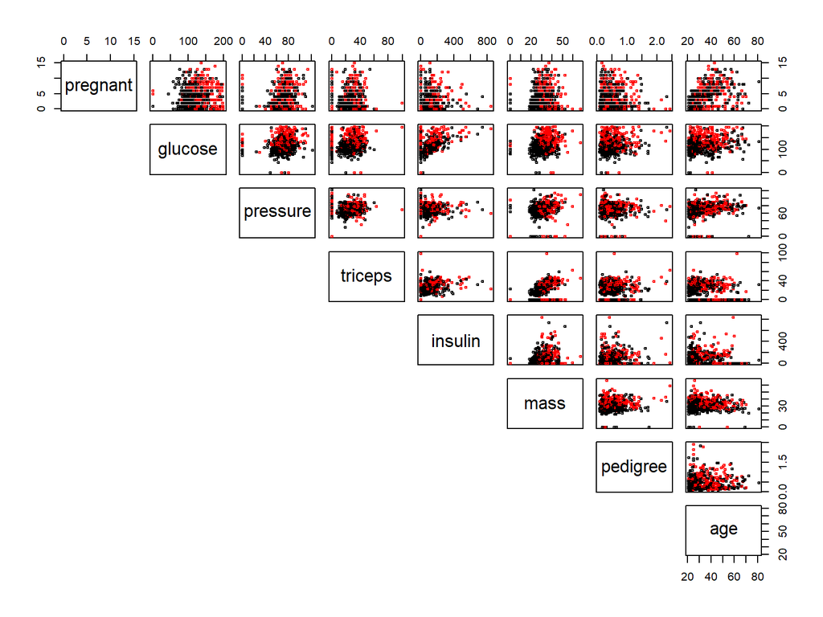

```r
# `pairs` creates a scatter plot matrix
# `select_if` subsets the data to include only numeric variables
pairs(select_if(train.data, is.numeric),
      cex = 0.5, col = train.data$diabetes, lower.panel=NULL)
```

## Problems with the Data

- Upon inspecting the scatterplot matrix, it is clear that missing data are being coded as “0”
  - Using only complete cases would cut the size of our training set *in half*
  - A more reasonable alternative is to **impute**, or “fill in”, the missing values
  - There are downsides to imputing missing data, but that is a discussion for another day
  - We need to be careful when imputing, for example, for the variable `pregnant` a value of “0” might not indicate missing data

```r
## The number of women with 0 prior pregnancies doesn't appear unusual
table(train.data$pregnant)
```

```
##
##   0   1   2   3   4   5   6   7   8   9  10  11  12  13  14  15
##  92 109  79  56  55  49  40  38  28  23  20  10   6   8   1   1
```

## Missing Data Imputation

- Imputation predicts the missing values using a model
- There are dozens of imputation models, we’ll use k-nearest neighbors

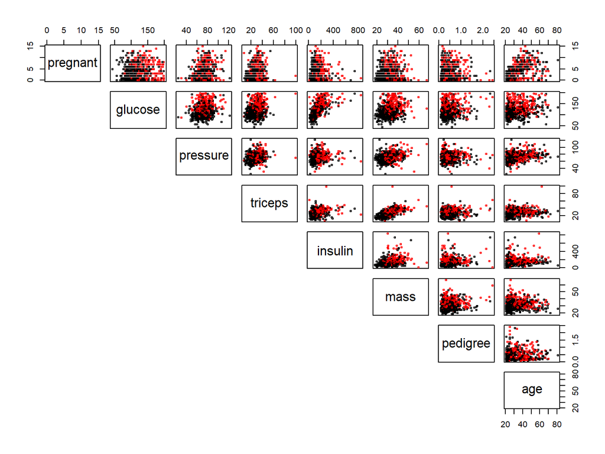

```r
train.data[train.data == 0] <- NA ## Fill all zeros with `NA`
train.data$pregnant[is.na(train.data$pregnant)] <- 0 ## Correct the variable `pregnant`

train.data2 <- knnImputation(train.data) ## Imputes missing values using predictions from knn
# The scatterplot matrix now looks much better
pairs(select_if(train.data2, is.numeric),
      cex = 0.5, col = train.data2$diabetes, lower.panel=NULL)
```

## Model Building

- At this point the data look ready to for modeling

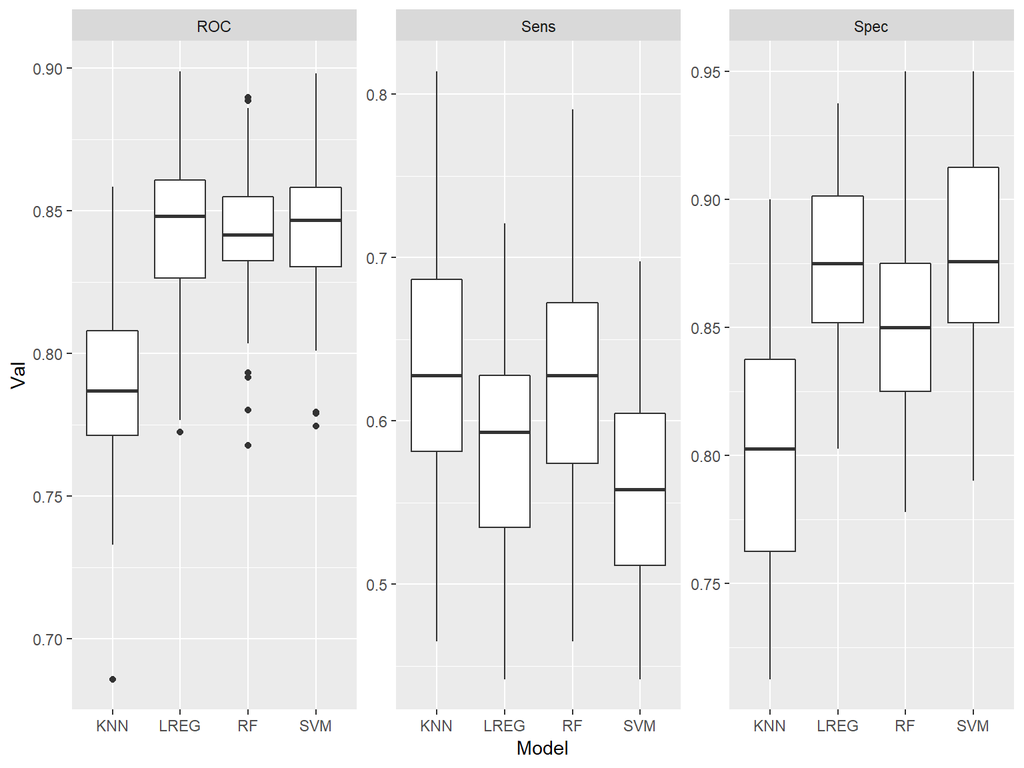

```r
## Set-up our train control, we'll be using AUC/sensitivity
fit.control <- trainControl(method = "repeatedcv", number = 5, repeats = 10, classProbs = TRUE, savePredictions = TRUE,  summaryFunction=twoClassSummary)

## Rearrange the levels so that pos for diabetes is the "positive" class
train.data2$diabetes <- factor(train.data2$diabetes, levels = c("pos","neg"))

## Fit a variety of classification models
set.seed(14)
knn.fit <- train(diabetes ~ ., data = train.data2, method = "knn", trControl = fit.control)
set.seed(14)
lreg.fit <- train(diabetes ~ ., data = train.data2, method = "glm", family = "binomial", trControl = fit.control)
set.seed(14)
rf.fit <- train(diabetes ~ ., data = train.data2, method = "rf", trControl = fit.control)
set.seed(14)
svm.fit <- train(diabetes ~ ., data = train.data2, method = "svmLinear", trControl = fit.control)

## Compare these models using resamples
resamps <- resamples(list(KNN = knn.fit, LREG = lreg.fit,
                          RF = rf.fit, SVM = svm.fit))

## Process the resamples results for visualization
resamps2 <- gather(resamps$values, key = "Var", value = "Val", 2:ncol(resamps$values))
resamps2 <- separate(resamps2, col = "Var", into = c("Model", "Metric"), sep = "~")

## The logistic regression model (LREG) has the best AUC, but it's sensitivity isn't good...
ggplot(resamps2, aes(x = Model, y = Val)) + geom_boxplot() + facet_wrap(~ Metric, scales = "free")
```

## Model Building

- The `LREG`, `RF`, and `SVM` models all look promising, but they all have poor sensitivity
- We might consider customizing the tuning grid used for some or all of these models, but we won’t do that here
- Instead, we’ll consider lowering the threshold to maximize sensitivity while retaining classification accuracy above 75%
- The `thresholder` function can help us decide how alter the probability threshold that is used for classifying predictions

```r
#install.packages('caret')
thresholder(svm.fit, seq(.3,.5,by = .025), statistics = c("Sensitivity", "Specificity", "Accuracy"))
```

```
##   C prob_threshold Sensitivity Specificity  Accuracy
## 1 1          0.300   0.7836988   0.6970370 0.7271776
## 2 1          0.325   0.7514175   0.7356667 0.7411419
## 3 1          0.350   0.7192248   0.7715895 0.7533545
## 4 1          0.375   0.6930454   0.7992963 0.7623176
## 5 1          0.400   0.6701329   0.8224969 0.7694750
## 6 1          0.425   0.6401661   0.8421975 0.7719167
## 7 1          0.450   0.6120709   0.8569043 0.7717487
## 8 1          0.475   0.5872979   0.8701049 0.7717316
## 9 1          0.500   0.5648062   0.8820833 0.7717355
```

```r
thresholder(lreg.fit, seq(.3,.5,by = .025), statistics = c("Sensitivity", "Specificity", "Accuracy"))
```

```
##   parameter prob_threshold Sensitivity Specificity  Accuracy
## 1      none          0.300   0.7748283   0.7132438 0.7346694
## 2      none          0.325   0.7542746   0.7416605 0.7460506
## 3      none          0.350   0.7304430   0.7686019 0.7553190
## 4      none          0.375   0.7028793   0.7950617 0.7629707
## 5      none          0.400   0.6780731   0.8135185 0.7663854
## 6      none          0.425   0.6523699   0.8329630 0.7701161
## 7      none          0.450   0.6261905   0.8539136 0.7746835
## 8      none          0.475   0.6032337   0.8666173 0.7749929
## 9      none          0.500   0.5826246   0.8768364 0.7745011
```

```r
thresholder(rf.fit, seq(.3,.5,by = .025), statistics = c("Sensitivity", "Specificity", "Accuracy"))
```

```
##   mtry prob_threshold Sensitivity Specificity  Accuracy
## 1    2          0.300   0.8374529   0.6790802 0.7341936
## 2    2          0.325   0.8215393   0.7037716 0.7447670
## 3    2          0.350   0.7926135   0.7254784 0.7488427
## 4    2          0.375   0.7669103   0.7464290 0.7535515
## 5    2          0.400   0.7295017   0.7688796 0.7551776
## 6    2          0.425   0.7052381   0.7918333 0.7616871
## 7    2          0.450   0.6786600   0.8105340 0.7646207
## 8    2          0.475   0.6529236   0.8307438 0.7688458
## 9    2          0.500   0.6201661   0.8531636 0.7720768
```

## The Final model

- The random forest model with a probability cutoff of 0.375 offers the best sensitivity while still achieving 75% cross-validated classification accuracy
- Having settled upon this model, we can now assess the model on the test data

```r
## Imputation on test data
test.data[test.data == 0] <- NA ## Fill all zeros with `NA`
test.data$pregnant[is.na(test.data$pregnant)] <- 0 ## Correct the variable `pregnant`

test.data2 <- knnImputation(test.data)

test.p <- predict(rf.fit, newdata = test.data2, type = "prob")
test.c <- ifelse(test.p$pos > 0.375, "pos", "neg")

tab <- table(test.c, test.data2$diabetes) ## Confusion matrix
sens <- sensitivity(tab) # Calculate test set sensitivity
spec <- specificity(tab) # Calculate test set specificity
acc <- mean(test.c == test.data2$diabetes) # Test set accuracy
print(data.frame(acc, sens, spec))
```

```
##         acc      sens      spec
## 1 0.7254902 0.6666667 0.8333333
```

## Understanding the Results

- Even if the goal is prediction, we should check and see which variables are most influencing the predictions
- The `varImp` function in the `caret` package offers built-in [variable importance](https://topepo.github.io/caret/variable-importance.html) measures for various models
- These normalized scores can be difficult to explain, but they can help guide visualizations of individual variable effects

```r
varImp(rf.fit)
```

```
## rf variable importance
##
##          Overall
## glucose  100.000
## insulin   95.758
## mass      57.148
## triceps   38.560
## age       38.437
## pedigree  32.317
## pressure   4.598
## pregnant   0.000
```

## Simple Visuals

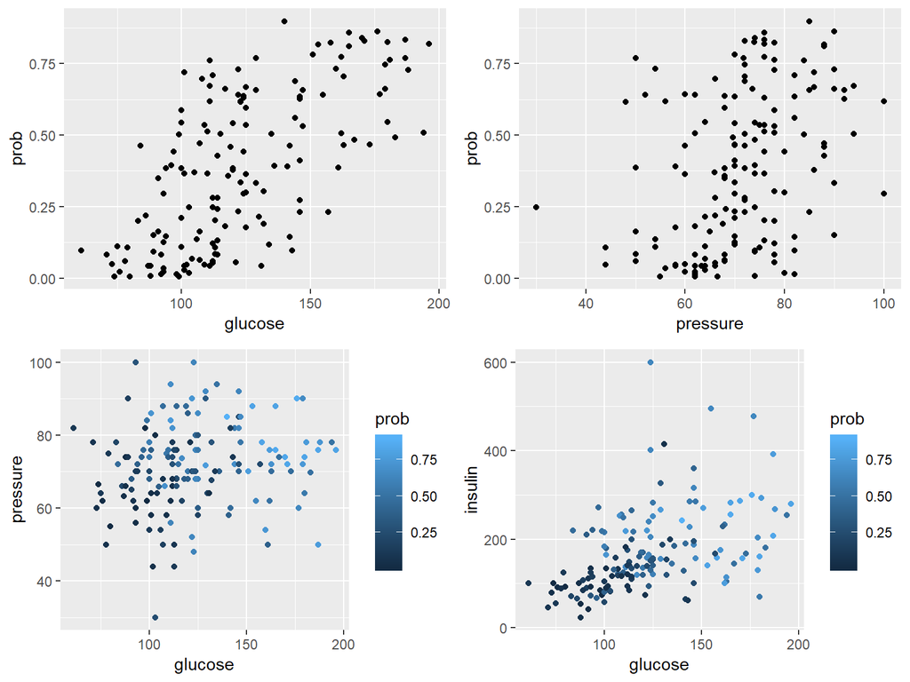

```r
library(gridExtra) ## To arrange ggplot objects
test.data2$prob <- test.p$pos

p1 <- ggplot(test.data2, aes(x = glucose, y = prob)) + geom_point() ## glucose vs predicted prob
p2 <- ggplot(test.data2, aes(x = pressure, y = prob)) + geom_point() ## blood pressure vs predicted prob
p3 <- ggplot(test.data2, aes(x = glucose, y = pressure, col = prob)) + geom_point() ## glucose and BP vs predicted prob
p4 <- ggplot(test.data2, aes(x = glucose, y = insulin, col = prob)) + geom_point() ## glucose and insulin vs predicted prob

grid.arrange(p1,p2,p3,p4, nrow = 2)
```

## Partial Dependence Plots

- Partial Dependence Plots (PDP) show the average predicted probability when all observations are forced to have a particular value of the variable being plotted (while retaining their values of all other variables)

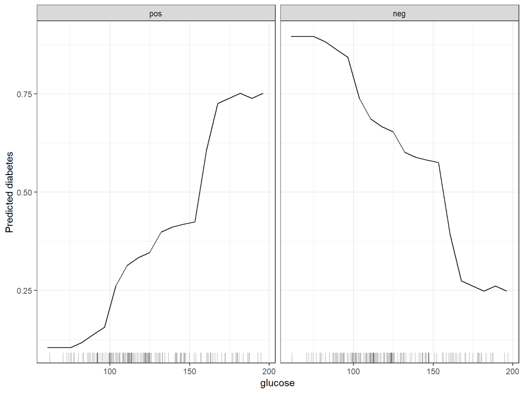

```r
model <- Predictor$new(model = rf.fit, data = test.data2)

e1 <- FeatureEffect$new(model, "glucose", method = "pdp")
plot(e1) + theme_bw()
```

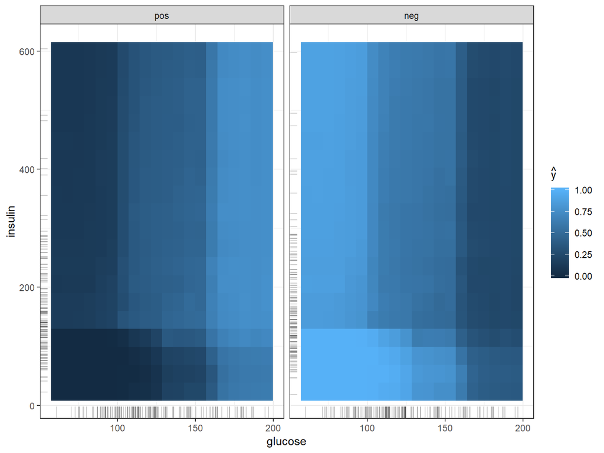

```r
e2 <- FeatureEffect$new(model, c("glucose","insulin"), method = "pdp")
plot(e2) + theme_bw()
```

## Accumulated Local Effects Plots

- PDPs are easy to understand - they show the average *marginal effect* at particular value of a predictor variable across all of the data points
  - Unfortunately, they rely on unrealistic extrapolations when variables are correlated
  - Imagine correlated predictor variables “# bedrooms” and “living area”
  - The PDP effect for a living area of 800 sqft is found replacing the living areas of all data points with 800 while leaving their values for other variables unchanged
  - Plugging in such a small living area makes no sense for a house with 8 bedrooms
- Accumulated Local Effects plots (ALEs) show the average *conditional effect* at a particular value of the predictor variable (estimated locally using a neighborhood)
  - The ALE for a living area of 800 sqft only uses houses with areas of about 800, estimating the living area effect via the difference in the predictions when pretending these houses are all 850 sqft versus pretending they are all 750 sqft
  - Differencing is intended to isolate the effect of variable of interest
  - ALE is centered, the value of the ALE can be interpreted as the main effect of the feature at a certain value compared to the average prediction of the data

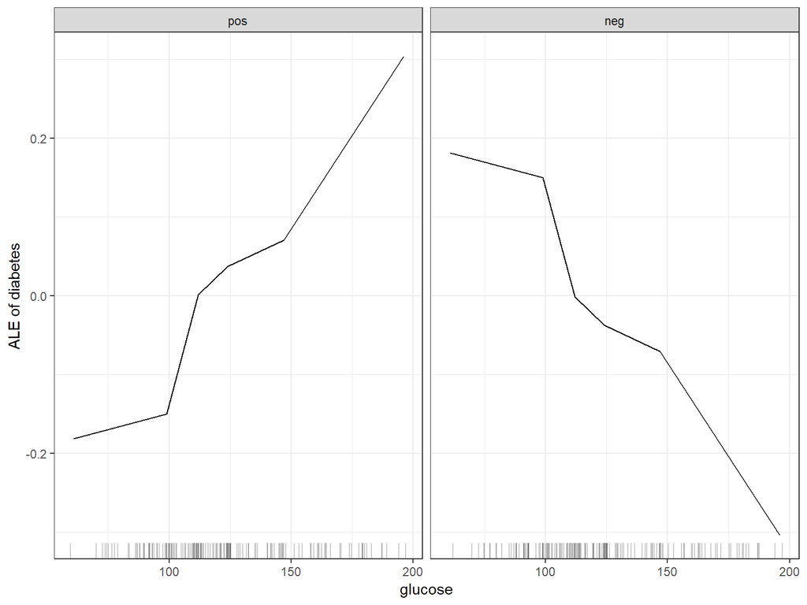

```r
model <- Predictor$new(model = rf.fit, data = test.data2)

## The grid size argument defines how many neighborhood
## We can see 5 line segments in this plot
e1 <- FeatureEffect$new(model, "glucose", method = "ale", grid.size = 5)
plot(e1) + theme_bw()
```

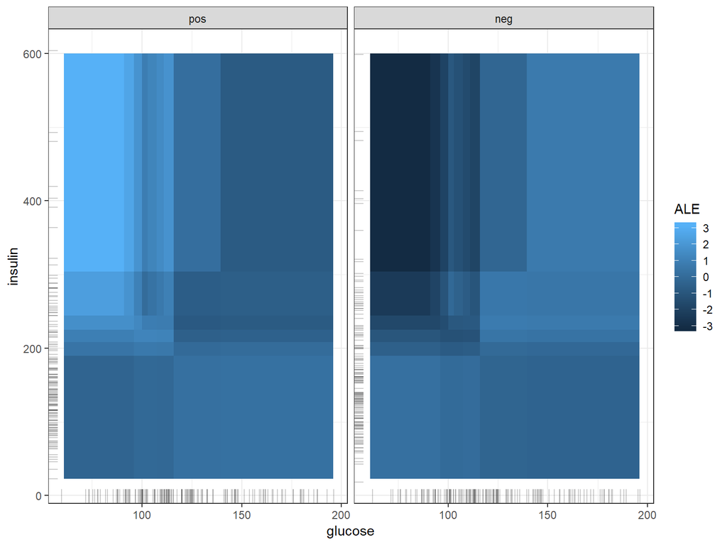

```r
## Caution, not much data is in the top left!
e2 <- FeatureEffect$new(model, c("glucose", "insulin"), method = "ale")
plot(e2) + theme_bw()
```